# Exploration of the Text Data

# Introduction

This report shows frequency analyses for 2-, 3-, and 4-grams for the three datasets, as well as for a combined dataset. I’ve omitted the R code from the output since there is a lot of it.

I’ve used the ngram package for processing the text and getting the n-grams.

# The Files

Here’s just a summary of the files:

- Blogs has 14000 lines and 574164 words.
- Twitter has 30000 lines and 384982 words.
- News has 16000 lines and 384982 words.

# Reading and Processing

I’ll read in proportions of each file to get roughly the same amount of data from each source. The number of lines I’ve used are as follows:

- Blogs: 14000
- Twitter: 30000
- News: 16000

After reading the files I’ve removed punctuations and lower-cased them.

# N-gram Plots

## Blogs

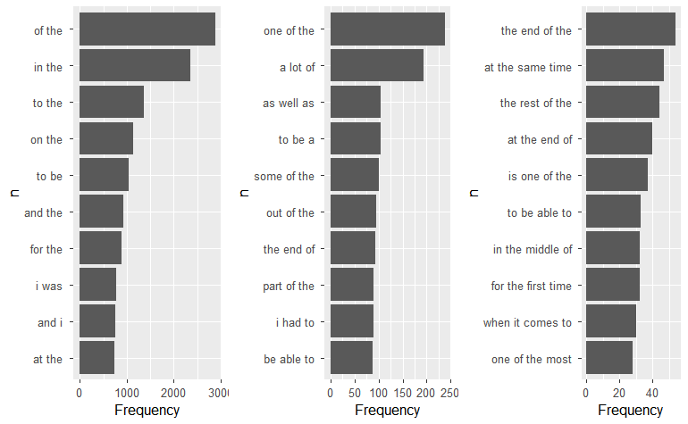

## Twitter

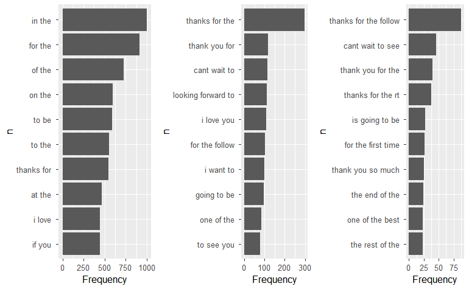

## News

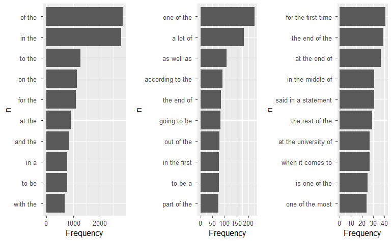

## Combined Data

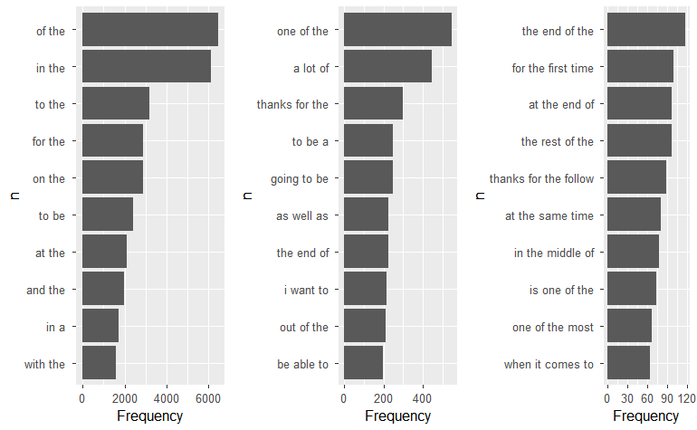

## Conclusions

It is not surprising seeing the word “the” high on the list. We also expect the sources to be different, and especially the 4-grams confirm this, as we can even see from some of the 4-grams where they come from.

# Prediction Algorithm

The plan is to use the combined dataset, and then the following algorithm:

Assume the input has three words, then check to see if there is a 4-gram where the three first words match. If so, use the fourth word as the prediction, and continue.

If there is no 4-gram, repeat the same but look for a 3-gram.

If no 3-gram, look for a 2-gram.

If no 2-gram, meaning the word isn’t in the model dictionary, there are multiple things that could be done. If the assignment doesn’t require that we produce a prediction all the time, then we could just not predict anything in this scenario. Alternatively, we could predict a high-frequency preposition or article like “the”, but even better would be to have a character-based model in this scenario. State-of-the-art transformer models like BERT for example use a form of subword encoding that is learnt from raw data.